# Visualizing Bivariate Relationships

# Agenda

- Simple bivariate regression
- Categorical IV

# Learning objectives

By the end of the lecture, you will be able to …

- Use R to produce bivariate regression
- Create visualizations that communicate bivariate relationships
- Visualize and interpret differences across categories

# Code-along 06.2

Download and open [code-along-06.2.qmd](https://www.dropbox.com/scl/fi/1ggss8320lsnl3r335ayl/code-along-06.2.qmd?rlkey=o93jexxglw32ume2auh38imoi&st=lki7h5tm&dl=1)

## Packages

Load the standard packages & new package `moderndive`

```r
# install.packages(broom.helpers) # needed for moderndive
# install.packages("moderndive")

library(tidyverse)
library(haven) # not core tidyverse
library(summarytools)
library(gtsummary)

# do not load moderndive(), use it specifically
```

# Simple Regression

## Simple Regression

Regression and correlation are ways to identify whether two interval-ratio variables are statistically dependent

> as the value of one variable changes, the other also tends to change

## Code Meets Question

What is the relationship between literacy rate and rate of tertiary education?

**literacy rate**  
% of adult population that is literate

**rate of tertiary education**  
the % of students enrolled/eligible within the age range

## Example df

```r
# Create columns
literacy <- c(31.7, 79.3, 85.4, 41.0, 54.7, 97.9, 92.8, 67.1, 97.8, 60.4, 87.5, 99.1)
educ <- c(3.74, 10.4, 20.4, 4.46, 9.53, 78.6, 31.5, 16.2, 65.8, 10.3, 30.8, 40.1)

# Combine into a data frame
df <- data.frame(literacy, educ)

# View the data frame
print(df)
```

```
   literacy  educ
1      31.7  3.74
2      79.3 10.40
3      85.4 20.40
4      41.0  4.46
5      54.7  9.53
6      97.9 78.60
7      92.8 31.50
8      67.1 16.20
9      97.8 65.80
10     60.4 10.30
11     87.5 30.80
12     99.1 40.10
```

## `tidy_summary()`

`moderndive::tidy_summary()` returns commonly used summary statistics in a tidy format.

```r
df |>
  moderndive::tidy_summary()
```

```
# A tibble: 2 × 11
  column       n group type      min    Q1  mean median    Q3   max    sd
  <chr>    <int> <chr> <chr>   <dbl> <dbl> <dbl>  <dbl> <dbl> <dbl> <dbl>
1 literacy    12 <NA>  numeric 31.7   59.0  74.6   82.4  94.0  99.1  23.2
2 educ        12 <NA>  numeric  3.74  10.1  26.8   18.3  33.6  78.6  24.2
```

```r
# Create scatterplot
df |>
  ggplot(aes(x = literacy, y = educ)) +
  geom_point(color = "#18BC9C", size = 3) +
  labs(
    title = "Scatterplot of Education vs Literacy",
    x = "Literacy Rate (X)",
    y = "College enrollment (Y)"
  ) +
  theme_minimal(20)
```

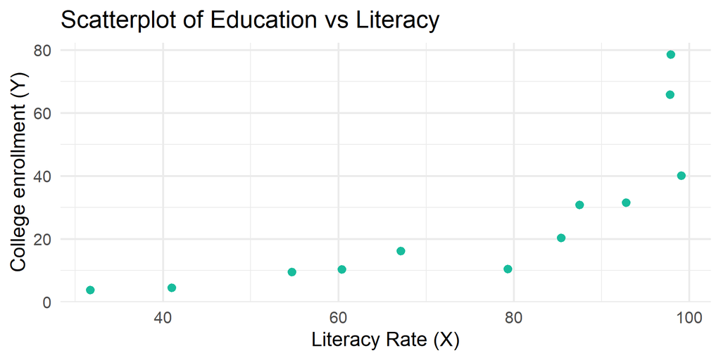

**Linear relationship**

When two interval-ratio level variables are related to one another we can approximate the relationship by drawing a straight line through the center of the observations on the scatterplot.

A bivariate regression analysis finds the best possible line to summarize the observed relationship between X and Y

```r
# Create scatterplot with regression line
df |>
  ggplot(aes(x = literacy, y = educ)) +
    geom_point(color = "#18BC9C", size = 3) +
    geom_smooth(method = "lm", se = FALSE, color = "#3498DB") +
    labs(
      title = "Scatterplot of Education vs Literacy with Regression Line",
      x = "Literacy Rate (X)",
      y = "College enrollment (Y)"
    ) +
    theme_minimal(20)
```

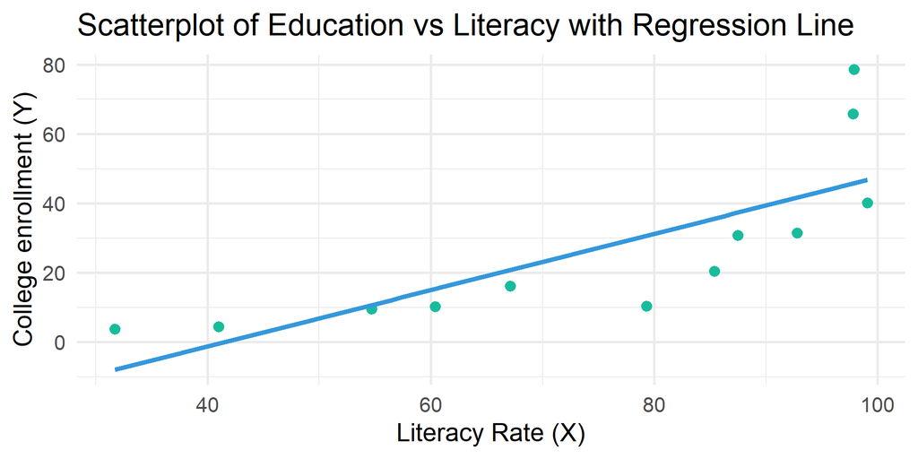

$\hat{y} = a + bX$

$\hat{y}$ = the predicted score on the dependent variable

$X$ = the score on the independent variable

$a$ = the Y-intercept, or the point where the line crosses the Y-axis ($a$ is the value of $Y$ when $X$ is equal to 0).

$b$ = the slope of the regression line, or the change in $Y$ for each unit of change in $X$.

$\hat{y} = a + bX$

Positive relationship  
When $b$ is positive, then when $X$ increases, $\hat{y}$ increases

Negative relationship  
When $b$ is negative, then when $X$ increases, $\hat{y}$ decreases

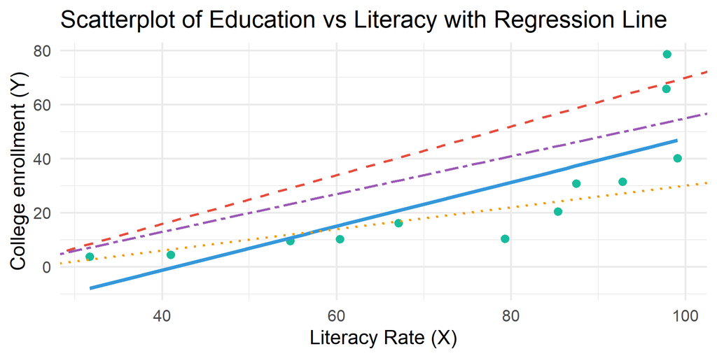

$\hat{y} = a + bX$

Regression finds the best fitting line that goes through the data with the least distance (error) between all points and the line.

AKA the “least squares line” referring to the least amount of squared error.

## Residual = error ($e$)

Calculated based on the difference between $Y$ and $\hat{y}$

$Y$ = observed value of $Y$ for given value of $X$

$\hat{y}$ = predicted value of $Y$ for given value of $X$

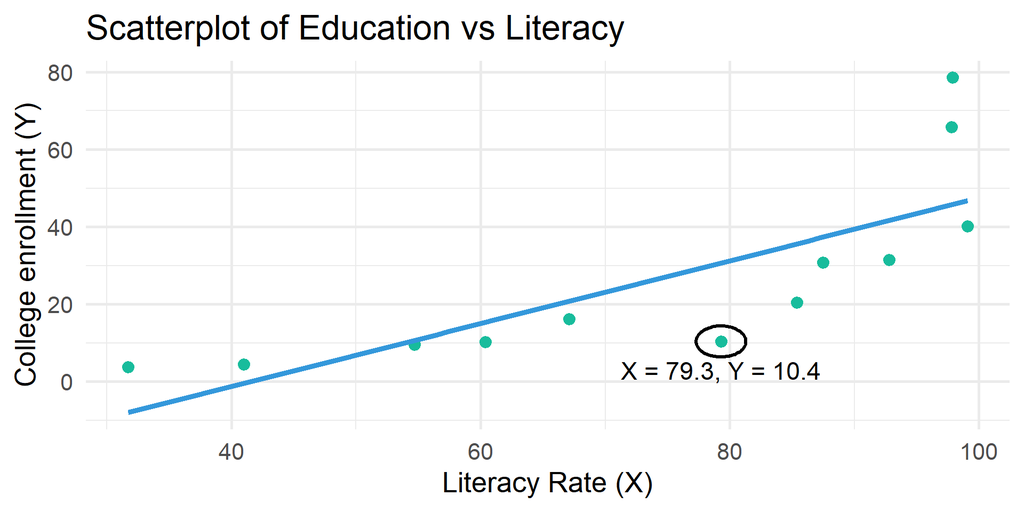

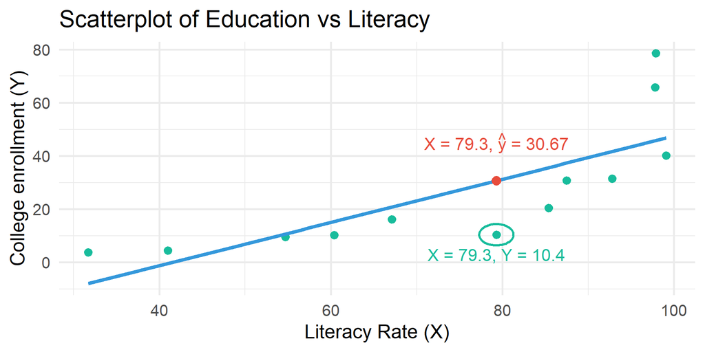

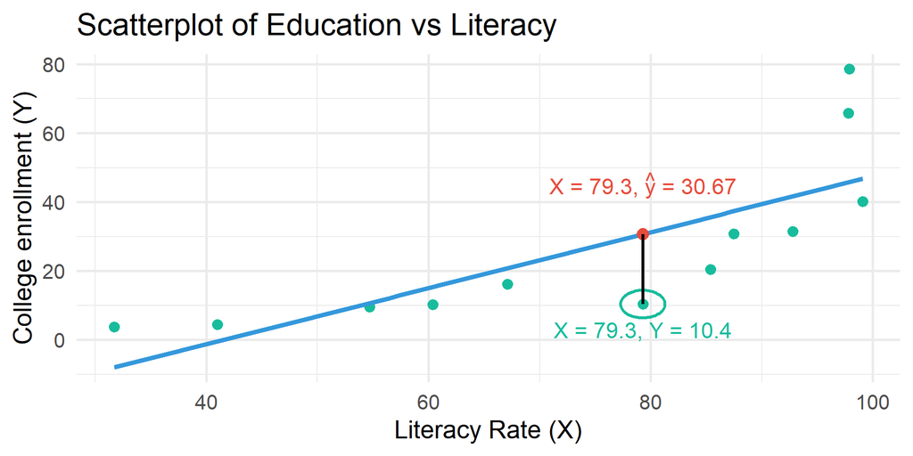

## Residual table

| literacy | educ | educ_hat | residual |
| --- | --- | --- | --- |
| 31.7 | 3.74 | -7.995 | 11.735 |
| 79.3 | 10.40 | 30.671 | -20.271 |
| 85.4 | 20.40 | 35.626 | -15.226 |
| 41.0 | 4.46 | -0.440 | 4.900 |
| 54.7 | 9.53 | 10.688 | -1.158 |
| 97.9 | 78.60 | 45.780 | 32.820 |

## OLS Regression

$\hat{y} = a + bX$

**Least-squares line**  
The line where the residual sum of squares is at a minimum

**Ordinary least-squares (OLS) regression**  
The statistical technique that produces the least-squares line Sometimes referred to as linear regression

$\hat{y} = a + bX$

Calculus demonstrates the formula for $b$ and $a$ will result in a regression line that minimizes the sum of squares.

Run a regression model.

```r
lm(educ ~ literacy, data = df)
```

```
Call:
lm(formula = educ ~ literacy, data = df)

Coefficients:
(Intercept)     literacy
   -33.7449       0.8123
```

$\hat{y} = -33.75 + .81X$

$\hat{y} = -33.75 + .81X$

For every one unit increase in the literacy rate, the college enrollment rate is expected to rise by 0.81 ($b$)

Is this statistically significant?

## `cor.test()`

Run and interpret the correlation for `educ` and `literacy`.

```r
cor.test(
     ~ educ + literacy,
     data = df,
     method = "pearson",
     na.action = na.omit
 )
```

```
    Pearson's product-moment correlation

data:  educ and literacy
t = 3.942, df = 10, p-value = 0.002766
alternative hypothesis: true correlation is not equal to 0
95 percent confidence interval:
 0.3731885 0.9352545
sample estimates:
      cor
0.7800287
```

## `get_regression_table()`

```r
model <- lm(educ ~ literacy, data = df)

moderndive::get_regression_table(model)
```

```
# A tibble: 2 × 7
  term      estimate std_error statistic p_value lower_ci upper_ci
  <chr>        <dbl>     <dbl>     <dbl>   <dbl>    <dbl>    <dbl>
1 intercept  -33.7      16.0       -2.10   0.062  -69.5       1.98
2 literacy     0.812     0.206      3.94   0.003    0.353     1.27
```

**statistic** Test whether the coefficient is different from 0. Get the t-values by dividing the estimate by its standard error.

**p-value** Two-tail p-values for the test statistic

## Prediction

$\hat{y} = -33.75 + .81X$

A regression equation can also be used to create predicted Y values for each value of X

If X = 60, $Y$ is predicted to be:

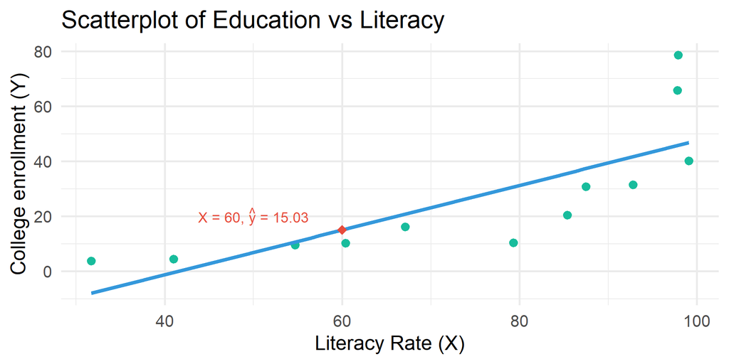

## Visualizing uncertainty

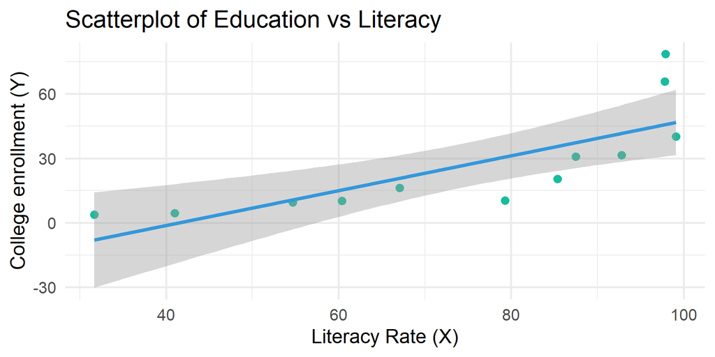

# Categorical IV

## Create a categorical variable

```r
# Use mutate and case_when to add the country_group column
df <- df |>
  mutate(
    # create the variable
    country_group = case_when(
      literacy < 50 ~ "Low Literacy",
      literacy >= 50 & literacy <= 80 ~ "Medium Literacy",
      literacy > 80 ~ "High Literacy"),
    # put the categories in a specific order
    country_group = factor(
      country_group,
      levels = c(
        "Low Literacy",
        "Medium Literacy",
        "High Literacy"))
    )


head(df)
```

## Create a categorical variable

```
  literacy  educ   country_group
1     31.7  3.74    Low Literacy
2     79.3 10.40 Medium Literacy
3     85.4 20.40   High Literacy
4     41.0  4.46    Low Literacy
5     54.7  9.53 Medium Literacy
6     97.9 78.60   High Literacy
```

## Visualize averages by category

```r
df |>
  group_by(country_group) |>
  summarize(
    mean_educ = mean(educ)) |>
  ggplot(
    aes(
      x = country_group,
      y = mean_educ,
      fill = country_group)) +
  geom_col(show.legend = FALSE) +
  labs(
    title = "Average College Enrollment by Literacy Group",
    x = "Literacy Group",
    y = "Enrollment (%)") +
  theme_minimal(20)
```

## Visualize averages by category

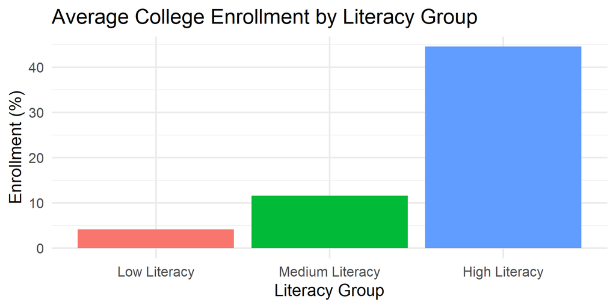

## `get_regression_table()`

```r
model_2 <- lm(educ ~ country_group, data = df)

moderndive::get_regression_table(model_2)
```

```
# A tibble: 3 × 7
  term                    estimate std_error statistic p_value lower_ci upper_ci
  <chr>                      <dbl>     <dbl>     <dbl>   <dbl>    <dbl>    <dbl>
1 intercept                   4.1       12.0     0.341   0.741   -23.1      31.3
2 country_group-Medium L…     7.51      14.7     0.51    0.622   -25.8      40.8
3 country_group-High Lit…    40.4       13.9     2.91    0.017     9.03     71.8
```

## Visualizing uncertainty

```r
df |>
  group_by(country_group) |>
  summarize(
    mean_educ = mean(educ),
    se = sd(educ) / sqrt(n()),
    lower = mean_educ - 1.96 * se,
    upper = mean_educ + 1.96 * se,
    .groups = "drop") |>
  ggplot(
    aes(
      x = country_group,
      y = mean_educ,
      fill = country_group)) +
  geom_col(show.legend = FALSE) +
  geom_errorbar(
    aes(
      ymin = lower,
      ymax = upper),
    width = .15,
    linewidth = 1) +
  labs(
    title = "Average College Enrollment by Literacy Group",
    x = "Literacy Group",
    y = "Enrollment (%)") +
  theme_minimal(20)
```

## Visualizing uncertainty

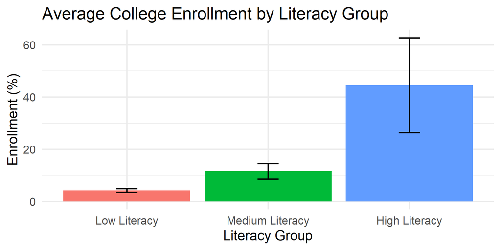

# Think Like a Statistician

## Think Like a Statistician

1. Run and interpret a simple regression using your IPUMS data

2. Run and interpret a regression with a categorical IV using your IPUMS data

3. Use ggplot() to communicate relationship between your DV and one IV. Use your regression results to support your interpretation.